# AOOI3_Aula04_ArtefatosIniciaisUML

Instituto Federal de São Paulo (IFSP)  
[Campus Bragança Paulista/SP](https://bra.ifsp.edu.br)  
**Análise e Desenvolvimento de Sistemas (ADS)**  
**3o. módulo**  
**Profa. Ana Paula Müller Giancoli**  
paulagiancoli@ifsp.edu.br

## AULA 04 - ARTEFATOS INICIAIS DA LINGUAGEM DE MODELAGEM UNIFICADA (UML)

### Agenda

- Artefatos Iniciais da UML
- Perguntas

### 1. Artefatos Iniciais da UML

### 1.1. Quais são os artefatos ?

- Artefato: **Documento Visão**. Consulte a **[Aula04_AOOI3_Aula04_Modelo-Visao]** para acessar ao modelo do documento.
- Artefato: **Documento Nomenclatura**
- Artefato: **Documento Glossário**. Consulte a **[AOOI3_Aula04_Modelo-Glossario]** para acessar ao modelo do documento.
- Lista de requisitos, regras de negócio e atores. Consulte a **[AOOI3_Aula04_Modelo-ListaRequisitos-RegrasNegocio]** para acessar ao modelo do documento.

### 1.1.1. Artefato: Documento Visão

- É um relato resumido com os **principais tópicos** em que o negócio a ser automatizado deve fornecer.
- Normalmente, faz parte de um contrato de desenvolvimento de *software*.
- **Poderá abordar**: aspectos da tecnologia (linguagens, banco de dados, etc) que serão usados.
- É um documento **voltado para** os contratantes do *software*.
- O **diagrama de Caso de Uso (nível 0)** ou Pacote de Sistema **baseia-se neste documento**.
- Apresenta de uma forma resumida o que o contratante (**REQUISITANTE**) deseja:

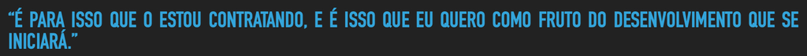

- É o que o contratado (**DESENVOLVEDOR**) quer:

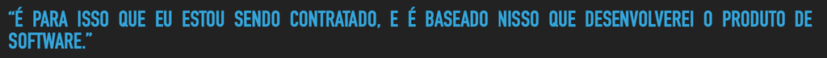

- Nasce na primeira reunião com os clientes de software (pessoas externas, internas, departamentos, etc).

### 1.1.2. Artefato: Documento Nomenclatura

- Serve para **criação de um padrão único** de pré e pós-fixação para as palavras envolvidas em estruturas de código.
- Serve principalmente, para novos colaboradores ao se juntarem a equipe, serem treinados em um mesmo padrão, sem existir vários códigos e estilos.
- **Cada empresa deve adotar uma notação** que permita o encontro da identidade do seu formato de nomenclatura.

### 1.1.3. Artefato: Documento Glossário

- Traduz para as pessoas que não conhecem o *software*, todos **os termos utilizados** pelo usuário contratante e outros *stakeholders*.
- Cada empresa adota o seu **vocabulário**.
- A finalidade deste documento **é agir como tradutor entre os participantes da análise, do desenho, da codificação, dos testes e dos herdeiros do *software* e o vocabulário particular da empresa**.

[output not shown]

### Referências

- Esta aula foi elaborada a partir do conteúdo disponibilizado em cada um dos links indicados no próprio texto.
- GUEDES, G. T. A. UML 2 - **UMA ABORDAGEM PRÁTICA**. [S.L.]: NOVATEC, 2011.
- MEDEIROS, Ernani - **Desenvolvendo Software com UML 2.0 Definitivo** - Editora Pearson Makron Books.
- BOOCH, Grady; RUMBAUGH, James; JACOBSON, Ivar - **UML Guia do Usuário** - 2a. Edição - Editora Campus (Elsevier).

### Perguntas

- Esclareça suas eventuais dúvidas durante as aulas.
- Ou pelo *E-mail*: paulagiancoli@ifsp.edu.br.
- Ou acesse [Github Ana Giancoli](https://anagiancoli.github.io) e solicite atendimento para o componente curricular.
- Ou pelo *Fórum* do componente curricular.

*ADS - AOO - 3o. módulo*.  
Modelo e formato elaborado por profa. Ana Paula Müller Giancoli - BSD 2-Clause License. - Setembro.2020.